# Allele-specific ChiPseq analysis. Check in on Genotype data

Anastasiia Hryhorzhevska

# 1. Load data

# 2. Convert STARR and GR SNP data into hg38 GRange object

## 2.1. STARR data

```r
starr <- makeGRangesFromDataFrame(starr.df, start.field = "position", end.field = "position", seqnames.field = c("chr"))
names(starr) <- starr.df$name
starr.hg38 <- deepblue_liftover(starr, source = "hg19", target = "hg38", collapse = T)
# seqnames(starr.hg38) <- substr(seqnames(starr.hg38), 4, length(seqnames(starr.hg38)))
seqlevels(starr.hg38) <- substr(seqlevels(starr.hg38), 4, length(seqlevels(starr.hg38)))
starr.hg38
```

```
## GRanges object with 234 ranges and 0 metadata columns:
##                seqnames    ranges strand
##                   <Rle> <IRanges>  <Rle>
##    1-148409926        1 150171103      *
##    1-148443906        1 150204998      *
##    1-148541113        1 150302061      *
##    1-148575582        1 150336486      *
##   12-111668114       12 112745926      *
##            ...      ...       ...    ...
##       rs246913        5 103224669      *
##     rs34509699        7  43733636      *
##       rs384097        3  41085240      *
##      rs9271171        6  32610130      *
##       rs948465       11 118095463      *
##   -------
##   seqinfo: 20 sequences from hg38 genome; no seqlengths
```

## 2.2.GR-SNP data

```r
grsnp.df$CHROM <- paste0("chr", grsnp.df$CHROM) #, 4, length(grsnp.df$CHROM))
grsnp <- makeGRangesFromDataFrame(grsnp.df, start.field = "POS", end.field = "POS", seqnames.field = c("CHROM"))
names(grsnp) <- grsnp.df$ID
grsnp.hg38 <- deepblue_liftover(grsnp , source = "hg19", target = "hg38", collapse = T)
# seqnames(starr.hg38) <- substr(seqnames(starr.hg38), 4, length(seqnames(starr.hg38)))
seqlevels(grsnp.hg38) <- substr(seqlevels(grsnp.hg38), 4, length(seqlevels(grsnp.hg38)))
grsnp.hg38
```

```
## GRanges object with 3657 ranges and 0 metadata columns:
##               seqnames    ranges strand
##                  <Rle> <IRanges>  <Rle>
##   1-148268256        1 150029674      *
##   1-148271849        1 150033260      *
##   1-148275208        1 150036614      *
##   1-148275840        1 150037246      *
##   1-148281790        1 150043194      *
##           ...      ...       ...    ...
##     rs9984686       21  44668453      *
##     rs9994839        4  87472628      *
##     rs9997288        4  55481060      *
##     rs9997384        4  47974068      *
##     rs9998146        4  55531810      *
##   -------
##   seqinfo: 22 sequences from hg38 genome; no seqlengths
```

# 3. Overlap STARR data with peaksets

## Check if SNPs are in the unique for DEX binding sites

```r
r1 <- starr.hg38
r2 <- peaks.list$dex
overlap <- findOverlaps(r1, r2, select = "all")
overlap
```

```
## Hits object with 8 hits and 0 metadata columns:
##       queryHits subjectHits
##       <integer>   <integer>
##   [1]        29       20872
##   [2]        32        1013
##   [3]        49       18128
##   [4]        64       13374
##   [5]        72       13189
##   [6]        82       11748
##   [7]       138       10530
##   [8]       184       20877
##   -------
##   queryLength: 234 / subjectLength: 24212
```

Make vector of SNPs to peaks

```r
hits <- names(r2)[subjectHits(overlap)]
names(hits) <- names(r1)[queryHits(overlap)]
hits
```

```
##  rs1183245 rs12126260   rs158401   rs227653  rs2422604  rs2901749  rs7256770
##    "38650"     "1965"    "33569"    "24984"    "24659"    "22148"    "19803"
##  rs1968126
##    "38660"
```

Manually check that it works well

```r
r1[names(hits),]
```

```
## GRanges object with 8 ranges and 0 metadata columns:
##              seqnames    ranges strand
##                 <Rle> <IRanges>  <Rle>
##    rs1183245        7  66076198      *
##   rs12126260        1 110881233      *
##     rs158401        5 103079764      *
##     rs227653       20  24949449      *
##    rs2422604       20   1520747      *
##    rs2901749        2  65065436      *
##    rs7256770       19  11579096      *
##    rs1968126        7  66592017      *
##   -------
##   seqinfo: 20 sequences from hg38 genome; no seqlengths
```

```r
r2[hits, ]
```

```
## GRanges object with 8 ranges and 3 metadata columns:
##         seqnames              ranges strand |      score    scoreA    scoreB
##            <Rle>           <IRanges>  <Rle> |  <numeric> <numeric> <numeric>
##   38650        7   66075598-66076243      * | 0.00256513        NA        NA
##    1965        1 110881136-110881671      * | 0.00271188        NA        NA
##   33569        5 103079622-103079960      * | 0.00240193        NA        NA
##   24984       20   24949092-24949495      * | 0.00189650        NA        NA
##   24659       20     1520682-1521183      * | 0.00399519        NA        NA
##   22148        2   65064785-65065660      * | 0.00469787        NA        NA
##   19803       19   11578866-11579197      * | 0.00424862        NA        NA
##   38660        7   66591904-66592433      * | 0.00258579        NA        NA
##   -------
##   seqinfo: 131 sequences from an unspecified genome; no seqlengths
```

## Find the distances to the nearest SNP for each peak for DEX

```r
nearest(r1, r2)[1:20]
```

```
##  [1]  1170  1171  1173  1173  5545 18128 20753 20754 20842 20874 20755 20756
## [13] 18128 20754 20879  7549  7932  4861  6740 11982
```

```r
dist.to.nearest.obj <- distanceToNearest(r1, r2)
dist.to.nearest.obj
```

```
## Hits object with 234 hits and 1 metadata column:
##         queryHits subjectHits |  distance
##         <integer>   <integer> | <integer>
##     [1]         1        1170 |      7903
##     [2]         2        1171 |      8629
##     [3]         3        1173 |      7815
##     [4]         4        1173 |     42240
##     [5]         5        5545 |     17439
##     ...       ...         ... .       ...
##   [230]       230       18128 |    144708
##   [231]       231       20756 |      1353
##   [232]       232       14905 |    105419
##   [233]       233       19201 |     17436
##   [234]       234        4332 |     77620
##   -------
##   queryLength: 234 / subjectLength: 24212
```

```r
dists <- dist.to.nearest.obj@elementMetadata@listData$distance
summary(dists)
```

```
##    Min. 1st Qu.  Median    Mean 3rd Qu.    Max.
##       0   10201   23486   48341   57673  644077
```

```r
# hist(dists,xlab = "dist to nearest peak", main = "Distances")
sort(dists)[1:20]
```

```
##  [1]    0    0    0    0    0    0    0    0   27  188  243  385 1088 1353 1392
## [16] 1620 1663 1844 1869 1878
```

```r
hits <- names(r2)[subjectHits(dist.to.nearest.obj)]
names(hits) <- names(r1)[queryHits(dist.to.nearest.obj)]
hits[1:3 ]
```

```
## 1-148409926 1-148443906 1-148541113
##      "2287"      "2288"      "2292"
```

Combine SNP, sites and distances into one dataframe

```r
# dist.df <- cbind(as.data.frame(hits), dists)
# dist.df

starr.dist <- cbind(as.data.frame(r1[names(hits), ]), dists) %>%
 mutate(CHR = seqnames, POS = start, DIST = dists) %>%
 dplyr::select(CHR, POS, DIST)

starr.bs.df <- cbind(starr.dist, as.data.frame(r2[hits, ]@seqnames), as.data.frame(r2[hits, ]@ranges))
colnames(starr.bs.df) <- c("CHR", "POS", "DIST", "PEAK_CHR", "PEAK_START", "PEAK_END", "PEAK_WIDTH", "PEAK_NAME")
starr.bs.df["TREATMENT"] <- "DEX"
starr.bs.df <- starr.bs.df[order(starr.bs.df$DIST), ]
starr.bs.df
```

|  | CHR | POS | DIST | PEAK_CHR | PEAK_START | PEAK_END | PEAK_WIDTH | PEAK_NAME | TREATMENT |
| --- | --- | --- | --- | --- | --- | --- | --- | --- | --- |
| rs1183245 | 7 | 66076198 | 0 | 7 | 66075598 | 66076243 | 646 | 38650 | DEX |
| rs12126260 | 1 | 110881233 | 0 | 1 | 110881136 | 110881671 | 536 | 1965 | DEX |
| rs158401 | 5 | 103079764 | 0 | 5 | 103079622 | 103079960 | 339 | 33569 | DEX |
| rs227653 | 20 | 24949449 | 0 | 20 | 24949092 | 24949495 | 404 | 24984 | DEX |
| rs2422604 | 20 | 1520747 | 0 | 20 | 1520682 | 1521183 | 502 | 24659 | DEX |
| rs2901749 | 2 | 65065436 | 0 | 2 | 65064785 | 65065660 | 876 | 22148 | DEX |
| rs7256770 | 19 | 11579096 | 0 | 19 | 11578866 | 11579197 | 332 | 19803 | DEX |
| rs1968126 | 7 | 66592017 | 0 | 7 | 66591904 | 66592433 | 530 | 38660 | DEX |
| rs9274649 | 6 | 32668440 | 27 | 6 | 32667082 | 32668412 | 1331 | 35675 | DEX |
| rs1000464 | 7 | 66312922 | 188 | 7 | 66313111 | 66313486 | 376 | 38654 | DEX |

[output cut: 224 more lines]

```r
write.csv2(starr.bs.df, paste0(result.dir, "01_STARR_SNP_TO_ChIP_BINDING_SITES_DISTANCES_DEX.csv"), row.names = T)
```

Plot frequencies:

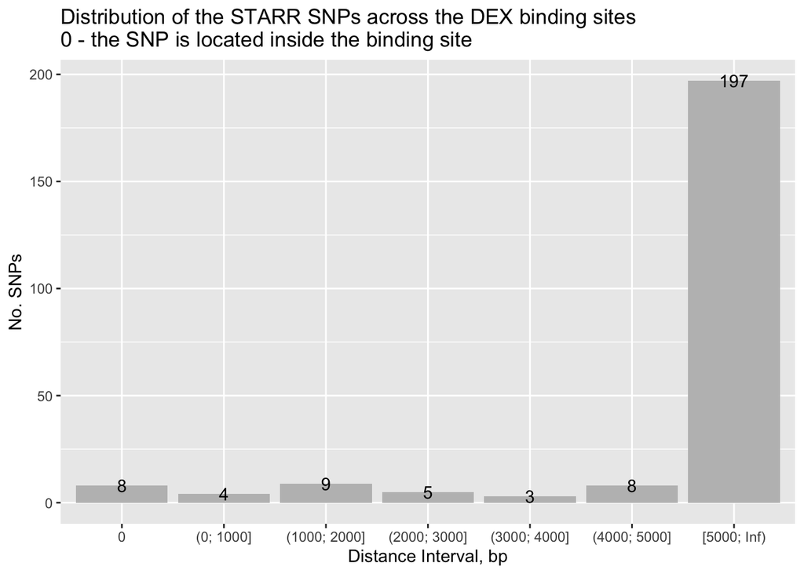

```r
starr.bs.bins <- data.frame(DistanceInterval = bin_data(data.table::data.table(starr.bs.df), binCol = "DIST", bins = c(0, 1, 1001, 2001, 3001, 4001, 5001, Inf), returnDT = F))
levels(starr.bs.bins$DistanceInterval) <- c("0", "(0; 1000]", "(1000; 2000]", "(2000; 3000]", "(3000; 4000]", "(4000; 5000]", "[5000; Inf)")

ggplot(starr.bs.bins, aes(DistanceInterval)) +
  geom_bar(fill = "grey") +
  stat_count(geom = "text",
             aes(label = stat(count)),
             position=position_nudge_repel(), colour="black") +
  ylab("No. SNPs") +
  xlab("Distance Interval, bp") +
  ggtitle("Distribution of the STARR SNPs across the DEX binding sites\n0 - the SNP is located inside the binding site",)
```

## Find the distances to the nearest SNP for each peak for VEH

```r
r1 <- starr.hg38
r2 <- peaks.list$veh
dist.to.nearest.obj <- distanceToNearest(r1, r2)
dists <- dist.to.nearest.obj@elementMetadata@listData$distance
summary(dist.to.nearest.obj)
```

```
## [1] "Hits object with 234 hits and 1 metadata column"
```

```r
hits <- names(r2)[subjectHits(dist.to.nearest.obj)]
names(hits) <- names(r1)[queryHits(dist.to.nearest.obj)]
```

Combine SNP, sites and distances into one dataframe

```r
# dist.df <- cbind(as.data.frame(hits), dists)
# dist.df

starr.dist <- cbind(as.data.frame(r1[names(hits), ]), dists) %>%
  dplyr::mutate(CHR = seqnames, POS = start, DIST = dists) %>%
  dplyr::select(CHR, POS, DIST)

starr.bs.df <- cbind(starr.dist, as.data.frame(r2[hits, ]@seqnames), as.data.frame(r2[hits, ]@ranges))
colnames(starr.bs.df) <- c("CHR", "POS", "DIST", "PEAK_CHR", "PEAK_START", "PEAK_END", "PEAK_WIDTH", "PEAK_NAME")
starr.bs.df["TREATMENT"] <- "VEH"
starr.bs.df <- starr.bs.df[order(starr.bs.df$DIST), ]
starr.bs.df
```

|  | CHR | POS | DIST | PEAK_CHR | PEAK_START | PEAK_END | PEAK_WIDTH | PEAK_NAME | TREATMENT |
| --- | --- | --- | --- | --- | --- | --- | --- | --- | --- |
| rs11769079 | 7 | 66377141 | 554 | 7 | 66376370 | 66376586 | 217 | 38656 | VEH |
| 3-113567114 | 3 | 112365577 | 1005 | 3 | 112364315 | 112364571 | 257 | 28782 | VEH |
| rs4437116 | 3 | 41119852 | 2021 | 3 | 41117524 | 41117830 | 307 | 27921 | VEH |
| rs13040726 | 20 | 25579245 | 5610 | 20 | 25584856 | 25585730 | 875 | 25007 | VEH |
| rs382964 | 5 | 102756366 | 5830 | 5 | 102762197 | 102762520 | 324 | 33566 | VEH |
| rs2292401 | 3 | 141234397 | 5997 | 3 | 141240395 | 141240603 | 209 | 29248 | VEH |
| rs447531 | 5 | 102755369 | 6827 | 5 | 102762197 | 102762520 | 324 | 33566 | VEH |
| rs2693477 | 3 | 40207162 | 7602 | 3 | 40199222 | 40199559 | 338 | 27910 | VEH |
| rs419099 | 5 | 102753738 | 8458 | 5 | 102762197 | 102762520 | 324 | 33566 | VEH |
| rs9275503 | 6 | 32706154 | 11543 | 6 | 32717698 | 32717884 | 187 | 35677 | VEH |

[output cut: 224 more lines]

```r
write.csv2(starr.bs.df, paste0(result.dir, "02_STARR_SNP_TO_ChIP_BINDING_SITES_DISTANCES_VEH.csv"), row.names = T)
```

Plot frequencies:

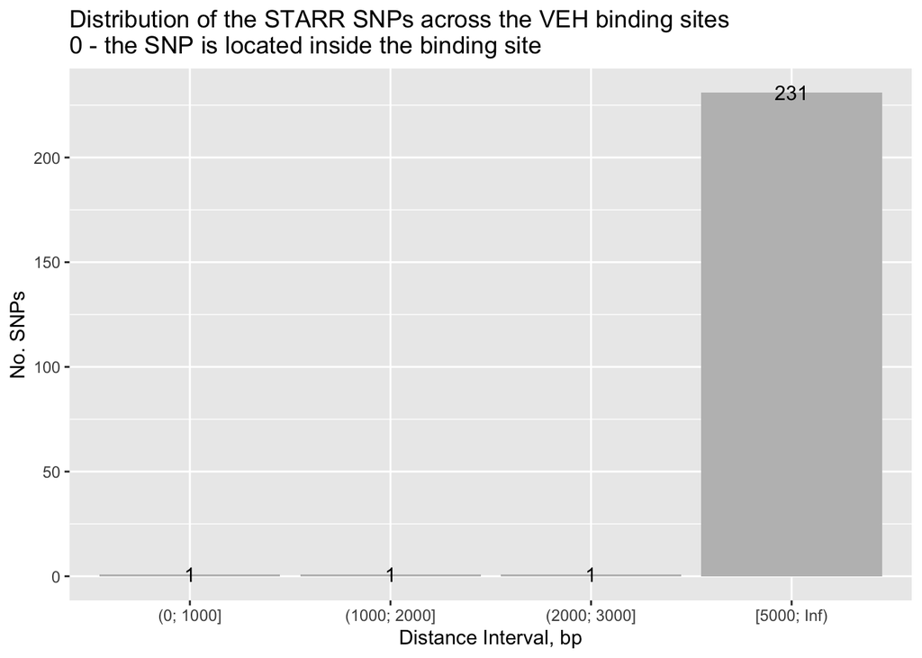

```r
starr.bs.bins <- data.frame(DistanceInterval = bin_data(data.table::data.table(starr.bs.df), binCol = "DIST", bins = c(0, 1, 1001, 2001, 3001, 4001, 5001, Inf), returnDT = F))
levels(starr.bs.bins$DistanceInterval) <- c("0", "(0; 1000]", "(1000; 2000]", "(2000; 3000]", "(3000; 4000]", "(4000; 5000]", "[5000; Inf)")

ggplot(starr.bs.bins, aes(DistanceInterval)) +
  geom_bar(fill = "grey") +
  stat_count(geom = "text",
             aes(label = stat(count)),
             position=position_nudge_repel(), colour="black") +
  ylab("No. SNPs") +
  xlab("Distance Interval, bp") +
  ggtitle("Distribution of the STARR SNPs across the VEH binding sites\n0 - the SNP is located inside the binding site",)
```

## Find the distances to the nearest SNP for each peak for VEH-DEX

```r
r1 <- starr.hg38
r2 <- peaks.list$`veh-dex`
dist.to.nearest.obj <- distanceToNearest(r1, r2)
dists <- dist.to.nearest.obj@elementMetadata@listData$distance
summary(dist.to.nearest.obj)
```

```
## [1] "Hits object with 234 hits and 1 metadata column"
```

```r
hits <- names(r2)[subjectHits(dist.to.nearest.obj)]
names(hits) <- names(r1)[queryHits(dist.to.nearest.obj)]
```

Combine SNP, sites and distances into one dataframe

```r
# dist.df <- cbind(as.data.frame(hits), dists)
# dist.df

starr.dist <- cbind(as.data.frame(r1[names(hits), ]), dists) %>%
  dplyr::mutate(CHR = seqnames, POS = start, DIST = dists) %>%
  dplyr::select(CHR, POS, DIST)

starr.bs.df <- cbind(starr.dist, as.data.frame(r2[hits, ]@seqnames), as.data.frame(r2[hits, ]@ranges))
colnames(starr.bs.df) <- c("CHR", "POS", "DIST", "PEAK_CHR", "PEAK_START", "PEAK_END", "PEAK_WIDTH", "PEAK_NAME")
starr.bs.df["TREATMENT"] <- "VEH-DEX"
starr.bs.df <- starr.bs.df[order(starr.bs.df$DIST), ]
starr.bs.df
```

|  | CHR | POS | DIST | PEAK_CHR | PEAK_START | PEAK_END | PEAK_WIDTH | PEAK_NAME | TREATMENT |
| --- | --- | --- | --- | --- | --- | --- | --- | --- | --- |
| rs2277911 | 7 | 66493638 | 0 | 7 | 66493420 | 66494143 | 724 | 38659 | VEH-DEX |
| rs28463765 | 4 | 55546267 | 0 | 4 | 55545758 | 55547259 | 1502 | 30828 | VEH-DEX |
| rs28746802 | 6 | 32665203 | 0 | 6 | 32664592 | 32665351 | 760 | 35674 | VEH-DEX |
| rs28746804 | 6 | 32665212 | 0 | 6 | 32664592 | 32665351 | 760 | 35674 | VEH-DEX |
| rs3846973 | 7 | 66655048 | 0 | 7 | 66653906 | 66655143 | 1238 | 38663 | VEH-DEX |
| rs57265446 | 20 | 24992833 | 0 | 20 | 24992074 | 24993128 | 1055 | 24986 | VEH-DEX |
| rs9271170 | 6 | 32610112 | 0 | 6 | 32609974 | 32610432 | 459 | 35670 | VEH-DEX |
| rs9271180 | 6 | 32610432 | 0 | 6 | 32609974 | 32610432 | 459 | 35670 | VEH-DEX |
| rs960749 | 2 | 171523271 | 0 | 2 | 171522281 | 171523602 | 1322 | 23504 | VEH-DEX |
| rs26524 | 5 | 103120600 | 0 | 5 | 103119622 | 103120864 | 1243 | 33570 | VEH-DEX |

[output cut: 224 more lines]

```r
write.csv2(starr.bs.df, paste0(result.dir, "03_STARR_SNP_TO_ChIP_BINDING_SITES_DISTANCES_VEH_DEX.csv"), row.names = T)
```

Plot frequencies:

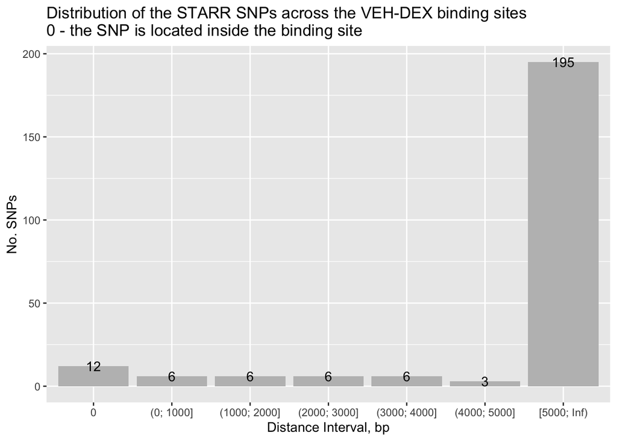

```r
starr.bs.bins <- data.frame(DistanceInterval = bin_data(data.table::data.table(starr.bs.df), binCol = "DIST", bins = c(0, 1, 1001, 2001, 3001, 4001, 5001, Inf), returnDT = F))
levels(starr.bs.bins$DistanceInterval) <- c("0", "(0; 1000]", "(1000; 2000]", "(2000; 3000]", "(3000; 4000]", "(4000; 5000]", "[5000; Inf)")

ggplot(starr.bs.bins, aes(DistanceInterval)) +
  geom_bar(fill = "grey") +
  stat_count(geom = "text",
             aes(label = stat(count)),
             position=position_nudge_repel(), colour="black") +
  ylab("No. SNPs") +
  xlab("Distance Interval, bp") +
  ggtitle("Distribution of the STARR SNPs across the VEH-DEX binding sites\n0 - the SNP is located inside the binding site",)
```

# 4. Overlap all GR-SNPs data with peaksets

```r
r1 <- grsnp.hg38
r2 <- peaks.list$dex
overlap <- findOverlaps(r1, r2, select = "all")
overlap
```

```
## Hits object with 42 hits and 0 metadata columns:
##        queryHits subjectHits
##        <integer>   <integer>
##    [1]        44        1169
##    [2]        46        1170
##    [3]       280       18787
##    [4]       660       20872
##    [5]       717        1013
##    ...       ...         ...
##   [38]      2898        4864
##   [39]      2967       12527
##   [40]      3065        2384
##   [41]      3450       19203
##   [42]      3616       15449
##   -------
##   queryLength: 3657 / subjectLength: 24212
```

Make vector of SNPs to peaks

```r
hits <- names(r2)[subjectHits(overlap)]
names(hits) <- names(r1)[queryHits(overlap)]
hits
```

```
## 1-148390386 1-148401915   rs1022549   rs1183245  rs12126260    rs158401
##      "2285"      "2287"     "34804"     "38650"      "1965"     "33569"
##   rs1873612   rs1948380   rs1968126   rs2138992   rs2228099    rs227650
##      "9093"      "9094"     "38660"      "3391"      "2306"     "24984"
##    rs227651    rs227652    rs227653   rs2296887   rs2395891   rs2422604
##     "24984"     "24984"     "24984"      "5777"     "19416"     "24659"
##   rs2638258   rs2708464  rs28746857  rs28746858  rs28746859  rs28746860
##      "9093"      "9093"     "35675"     "35675"     "35675"     "35675"
##  rs28746861  rs28746863  rs28746865  rs28746866  rs28746867   rs2901749
##     "35675"     "35675"     "35675"     "35675"     "35675"     "22148"
##     rs32677   rs3825073   rs3828794   rs3828796   rs6001679    rs716231
##     "33567"      "7259"     "35675"     "35675"     "27011"      "9093"
##   rs7256770    rs728623   rs7564847   rs7915524   rs9274619   rs9841230
##     "19803"      "9094"     "23503"      "4453"     "35675"     "28883"
```

```r
r1[names(hits),]
```

```
## GRanges object with 42 ranges and 0 metadata columns:
##               seqnames    ranges strand
##                  <Rle> <IRanges>  <Rle>
##   1-148390386        1 150151572      *
##   1-148401915        1 150163093      *
##     rs1022549        6   1714443      *
##     rs1183245        7  66076198      *
##    rs12126260        1 110881233      *
##           ...      ...       ...    ...
##      rs728623       12  40168211      *
##     rs7564847        2 171510013      *
##     rs7915524       10  15251904      *
##     rs9274619        6  32668177      *
##     rs9841230        3 119727594      *
##   -------
##   seqinfo: 22 sequences from hg38 genome; no seqlengths
```

```r
r2[hits, ]
```

```
## GRanges object with 42 ranges and 3 metadata columns:
##         seqnames              ranges strand |      score    scoreA    scoreB
##            <Rle>           <IRanges>  <Rle> |  <numeric> <numeric> <numeric>
##    2285        1 150150518-150152283      * | 0.00212841        NA        NA
##    2287        1 150162746-150163199      * | 0.00627874        NA        NA
##   34804        6     1714393-1714901      * | 0.00343692        NA        NA
##   38650        7   66075598-66076243      * | 0.00256513        NA        NA
##    1965        1 110881136-110881671      * | 0.00271188        NA        NA
##     ...      ...                 ...    ... .        ...       ...       ...
##    9094       12   40168088-40169203      * | 0.00495658        NA        NA
##   23503        2 171509821-171510342      * | 0.00287399        NA        NA
##    4453       10   15251792-15252364      * | 0.00414037        NA        NA
##   35675        6   32667082-32668412      * | 0.00610844        NA        NA
##   28883        3 119727533-119727924      * | 0.00217574        NA        NA
##   -------
##   seqinfo: 131 sequences from an unspecified genome; no seqlengths
```

## Find the distances to the nearest SNP for each peak for DEX

```r
r1 <- grsnp.hg38
r2 <- peaks.list$dex
dist.to.nearest.obj <- distanceToNearest(r1, r2)
dists <- dist.to.nearest.obj@elementMetadata@listData$distance
summary(dist.to.nearest.obj)
```

```
## [1] "Hits object with 3657 hits and 1 metadata column"
```

```r
hits <- names(r2)[subjectHits(dist.to.nearest.obj)]
names(hits) <- names(r1)[queryHits(dist.to.nearest.obj)]
hits[1:10]
```

```
## 1-148268256 1-148271849 1-148275208 1-148275840 1-148281790 1-148283858
##      "2280"      "2280"      "2280"      "2280"      "2283"      "2283"
## 1-148285660 1-148290924 1-148291801 1-148313743
##      "2283"      "2283"      "2283"      "2283"
```

Combine SNP, sites and distances into one dataframe

```r
# dist.df <- cbind(as.data.frame(hits), dists)
# dist.df

grsnp.dist <- cbind(as.data.frame(r1[names(hits), ]), dists) %>%
  dplyr::mutate(CHR = seqnames, POS = start, DIST = dists) %>%
  dplyr::select(CHR, POS, DIST)

grsnp.bs.df <- cbind(grsnp.dist, as.data.frame(r2[hits, ]@seqnames), as.data.frame(r2[hits, ]@ranges))
colnames(grsnp.bs.df) <- c("CHR", "POS", "DIST", "PEAK_CHR", "PEAK_START", "PEAK_END", "PEAK_WIDTH", "PEAK_NAME")
grsnp.bs.df["TREATMENT"] <- "DEX"
grsnp.bs.df <- grsnp.bs.df[order(grsnp.bs.df$DIST), ]
grsnp.bs.df
```

|  | CHR | POS | DIST | PEAK_CHR | PEAK_START | PEAK_END | PEAK_WIDTH | PEAK_NAME | TREATMENT |
| --- | --- | --- | --- | --- | --- | --- | --- | --- | --- |
| 1-148390386 | 1 | 150151572 | 0 | 1 | 150150518 | 150152283 | 1766 | 2285 | DEX |
| 1-148401915 | 1 | 150163093 | 0 | 1 | 150162746 | 150163199 | 454 | 2287 | DEX |
| rs1022549 | 6 | 1714443 | 0 | 6 | 1714393 | 1714901 | 509 | 34804 | DEX |
| rs1183245 | 7 | 66076198 | 0 | 7 | 66075598 | 66076243 | 646 | 38650 | DEX |
| rs12126260 | 1 | 110881233 | 0 | 1 | 110881136 | 110881671 | 536 | 1965 | DEX |
| rs158401 | 5 | 103079764 | 0 | 5 | 103079622 | 103079960 | 339 | 33569 | DEX |
| rs1873612 | 12 | 40158649 | 0 | 12 | 40157575 | 40159238 | 1664 | 9093 | DEX |
| rs1948380 | 12 | 40169104 | 0 | 12 | 40168088 | 40169203 | 1116 | 9094 | DEX |
| rs1968126 | 7 | 66592017 | 0 | 7 | 66591904 | 66592433 | 530 | 38660 | DEX |
| rs2138992 | 1 | 206821059 | 0 | 1 | 206820803 | 206821069 | 267 | 3391 | DEX |

[output cut: 3647 more lines]

```r
write.csv2(grsnp.bs.df, paste0(result.dir, "04_GRSNP_SNP_TO_ChIP_BINDING_SITES_DISTANCES_DEX.csv"), row.names = T)
```

Plot frequencies:

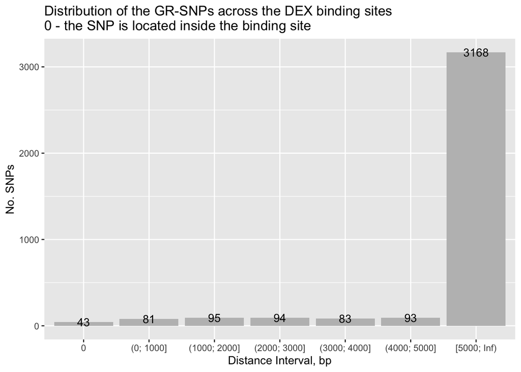

```r
grsnp.bs.bins <- data.frame(DistanceInterval = bin_data(data.table::data.table(grsnp.bs.df), binCol = "DIST", bins = c(0, 1, 1001, 2001, 3001, 4001, 5001, Inf), returnDT = F))
levels(grsnp.bs.bins$DistanceInterval) <- c("0", "(0; 1000]", "(1000; 2000]", "(2000; 3000]", "(3000; 4000]", "(4000; 5000]", "[5000; Inf)")

ggplot(grsnp.bs.bins, aes(DistanceInterval)) +
  geom_bar(fill = "grey") +
  stat_count(geom = "text",
             aes(label = stat(count)),
             position=position_nudge_repel(), colour="black") +
  ylab("No. SNPs") +
  xlab("Distance Interval, bp") +
  ggtitle("Distribution of the GR-SNPs across the DEX binding sites\n0 - the SNP is located inside the binding site",)
```

## Find the distances to the nearest SNP for each peak for VEH

```r
r1 <- grsnp.hg38
r2 <- peaks.list$veh
dist.to.nearest.obj <- distanceToNearest(r1, r2)
dists <- dist.to.nearest.obj@elementMetadata@listData$distance
summary(dist.to.nearest.obj)
```

```
## [1] "Hits object with 3657 hits and 1 metadata column"
```

```r
hits <- names(r2)[subjectHits(dist.to.nearest.obj)]
names(hits) <- names(r1)[queryHits(dist.to.nearest.obj)]
hits[1:10]
```

```
## 1-148268256 1-148271849 1-148275208 1-148275840 1-148281790 1-148283858
##      "2276"      "2276"      "2276"      "2276"      "2276"      "2276"
## 1-148285660 1-148290924 1-148291801 1-148313743
##      "2276"      "2276"      "2276"      "2276"
```

Combine SNP, sites and distances into one dataframe

```r
# dist.df <- cbind(as.data.frame(hits), dists)
# dist.df

grsnp.dist <- cbind(as.data.frame(r1[names(hits), ]), dists) %>%
  dplyr::mutate(CHR = seqnames, POS = start, DIST = dists) %>%
  dplyr::select(CHR, POS, DIST)

grsnp.bs.df <- cbind(grsnp.dist, as.data.frame(r2[hits, ]@seqnames), as.data.frame(r2[hits, ]@ranges))
colnames(grsnp.bs.df) <- c("CHR", "POS", "DIST", "PEAK_CHR", "PEAK_START", "PEAK_END", "PEAK_WIDTH", "PEAK_NAME")
grsnp.bs.df["TREATMENT"] <- "VEH"
grsnp.bs.df <- grsnp.bs.df[order(grsnp.bs.df$DIST), ]
grsnp.bs.df
```

|  | CHR | POS | DIST | PEAK_CHR | PEAK_START | PEAK_END | PEAK_WIDTH | PEAK_NAME | TREATMENT |
| --- | --- | --- | --- | --- | --- | --- | --- | --- | --- |
| rs12698521 | 7 | 66474502 | 0 | 7 | 66474365 | 66474576 | 212 | 38658 | VEH |
| rs6439986 | 3 | 141240459 | 0 | 3 | 141240395 | 141240603 | 209 | 29248 | VEH |
| rs6439987 | 3 | 141240502 | 0 | 3 | 141240395 | 141240603 | 209 | 29248 | VEH |
| rs2909688 | 7 | 66376625 | 38 | 7 | 66376370 | 66376586 | 217 | 38656 | VEH |
| rs60492890 | 19 | 1275369 | 100 | 19 | 1274970 | 1275268 | 299 | 19373 | VEH |
| rs12891572 | 14 | 21270103 | 154 | 14 | 21269726 | 21269948 | 223 | 11882 | VEH |
| rs4307445 | 9 | 136385324 | 238 | 9 | 136385563 | 136385839 | 277 | 43640 | VEH |
| rs10121371 | 9 | 2790559 | 310 | 9 | 2790870 | 2791199 | 330 | 41981 | VEH |
| rs12536316 | 7 | 65321405 | 345 | 7 | 65320803 | 65321059 | 257 | 38634 | VEH |
| rs466235 | 5 | 102762878 | 357 | 5 | 102762197 | 102762520 | 324 | 33566 | VEH |

[output cut: 3647 more lines]

```r
write.csv2(grsnp.bs.df, paste0(result.dir, "05_GRSNP_SNP_TO_ChIP_BINDING_SITES_DISTANCES_VEH.csv"), row.names = T)
```

Plot frequencies:

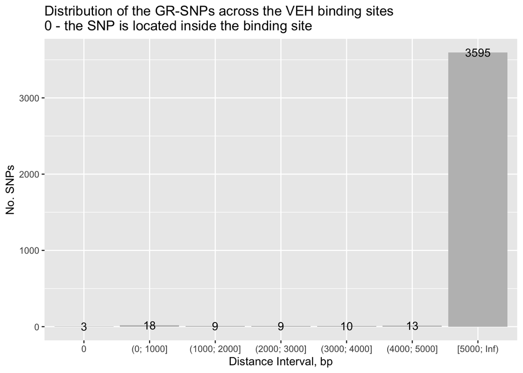

```r
grsnp.bs.bins <- data.frame(DistanceInterval = bin_data(data.table::data.table(grsnp.bs.df), binCol = "DIST", bins = c(0, 1, 1001, 2001, 3001, 4001, 5001, Inf), returnDT = F))
levels(grsnp.bs.bins$DistanceInterval) <- c("0", "(0; 1000]", "(1000; 2000]", "(2000; 3000]", "(3000; 4000]", "(4000; 5000]", "[5000; Inf)")

ggplot(grsnp.bs.bins, aes(DistanceInterval)) +
  geom_bar(fill = "grey") +
  stat_count(geom = "text",
             aes(label = stat(count)),
             position=position_nudge_repel(), colour="black") +
  ylab("No. SNPs") +
  xlab("Distance Interval, bp") +
  ggtitle("Distribution of the GR-SNPs across the VEH binding sites\n0 - the SNP is located inside the binding site",)
```

## Find the distances to the nearest SNP for each peak for DEX-VEH

```r
r1 <- grsnp.hg38
r2 <- peaks.list$`veh-dex`
dist.to.nearest.obj <- distanceToNearest(r1, r2)
dists <- dist.to.nearest.obj@elementMetadata@listData$distance
summary(dist.to.nearest.obj)
```

```
## [1] "Hits object with 3657 hits and 1 metadata column"
```

```r
hits <- names(r2)[subjectHits(dist.to.nearest.obj)]
names(hits) <- names(r1)[queryHits(dist.to.nearest.obj)]
hits[1:10]
```

```
## 1-148268256 1-148271849 1-148275208 1-148275840 1-148281790 1-148283858
##      "2281"      "2281"      "2281"      "2281"      "2282"      "2282"
## 1-148285660 1-148290924 1-148291801 1-148313743
##      "2282"      "2282"      "2282"      "2282"
```

Combine SNP, sites and distances into one dataframe

```r
# dist.df <- cbind(as.data.frame(hits), dists)
# dist.df

grsnp.dist <- cbind(as.data.frame(r1[names(hits), ]), dists) %>%
  dplyr::mutate(CHR = seqnames, POS = start, DIST = dists) %>%
  dplyr::select(CHR, POS, DIST)

grsnp.bs.df <- cbind(grsnp.dist, as.data.frame(r2[hits, ]@seqnames), as.data.frame(r2[hits, ]@ranges))
colnames(grsnp.bs.df) <- c("CHR", "POS", "DIST", "PEAK_CHR", "PEAK_START", "PEAK_END", "PEAK_WIDTH", "PEAK_NAME")
grsnp.bs.df["TREATMENT"] <- "VEH-DEX"
grsnp.bs.df <- grsnp.bs.df[order(grsnp.bs.df$DIST), ]
grsnp.bs.df
```

|  | CHR | POS | DIST | PEAK_CHR | PEAK_START | PEAK_END | PEAK_WIDTH | PEAK_NAME | TREATMENT |
| --- | --- | --- | --- | --- | --- | --- | --- | --- | --- |
| 1-148603913 | 1 | 150364813 | 0 | 1 | 150363666 | 150365702 | 2037 | 2294 | VEH-DEX |
| 6-32698276 | 6 | 32622521 | 0 | 6 | 32622432 | 32623960 | 1529 | 35671 | VEH-DEX |
| rs1006717 | 19 | 2841362 | 0 | 19 | 2840900 | 2841508 | 609 | 19483 | VEH-DEX |
| rs11130025 | 3 | 44338716 | 0 | 3 | 44337990 | 44339032 | 1043 | 27972 | VEH-DEX |
| rs11974866 | 7 | 50148829 | 0 | 7 | 50148477 | 50148994 | 518 | 38538 | VEH-DEX |
| rs12463059 | 19 | 35717547 | 0 | 19 | 35717021 | 35717911 | 891 | 20326 | VEH-DEX |
| rs12906126 | 15 | 75008916 | 0 | 15 | 75008458 | 75009450 | 993 | 14284 | VEH-DEX |
| rs12979308 | 19 | 1275988 | 0 | 19 | 1275430 | 1276352 | 923 | 19374 | VEH-DEX |
| rs1382573 | 1 | 150160129 | 0 | 1 | 150160036 | 150160833 | 798 | 2286 | VEH-DEX |
| rs17137491 | 6 | 4018334 | 0 | 6 | 4018095 | 4018881 | 787 | 34874 | VEH-DEX |

[output cut: 3647 more lines]

```r
write.csv2(grsnp.bs.df, paste0(result.dir, "06_GRSNP_SNP_TO_ChIP_BINDING_SITES_DISTANCES_VEH_DEX.csv"), row.names = T)
```

Plot frequencies:

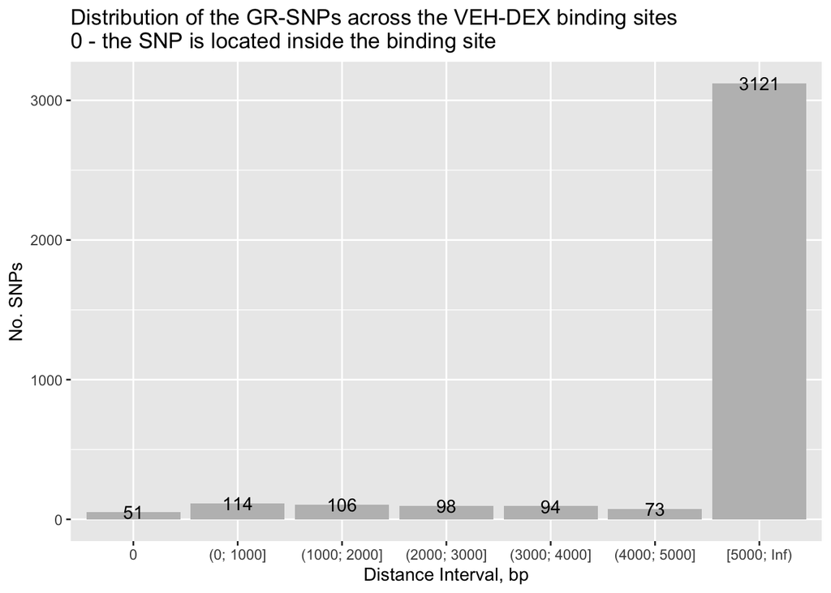

```r
grsnp.bs.bins <- data.frame(DistanceInterval = bin_data(data.table::data.table(grsnp.bs.df), binCol = "DIST", bins = c(0, 1, 1001, 2001, 3001, 4001, 5001, Inf), returnDT = F))
levels(grsnp.bs.bins$DistanceInterval) <- c("0", "(0; 1000]", "(1000; 2000]", "(2000; 3000]", "(3000; 4000]", "(4000; 5000]", "[5000; Inf)")

ggplot(grsnp.bs.bins, aes(DistanceInterval)) +
  geom_bar(fill = "grey") +
  stat_count(geom = "text",
             aes(label = stat(count)),
             position=position_nudge_repel(), colour="black") +
  ylab("No. SNPs") +
  xlab("Distance Interval, bp") +
  ggtitle("Distribution of the GR-SNPs across the VEH-DEX binding sites\n0 - the SNP is located inside the binding site",)
```